# Statistical Methods

Assumptions and Diagnostics I

Fall 2025 | Course PSYC 790  
Jeffrey M. Girard | Lecture 12a

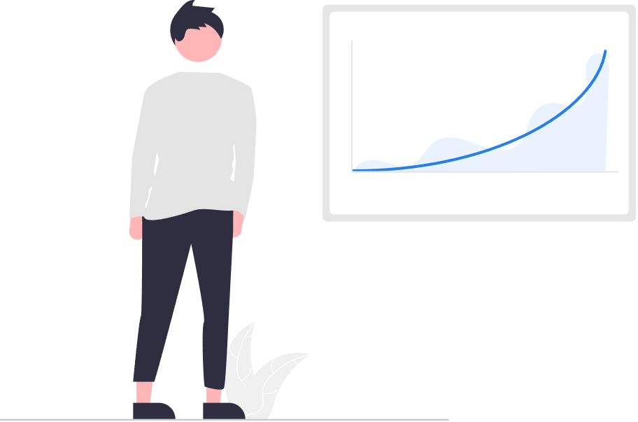

# Overview

## Motivation

- The linear model makes certain assumptions about the data
- When these assumptions are **violated**, two main problems occur
1. Estimated **coefficients** (i.e., relationships) may be biased
   - Intercepts and slopes directly affected
   - Tests and confidence intervals indirectly affected
2. Estimated **standard errors** (i.e., uncertainty) may be biased
   - Tests and confidence intervals directly affected
- Thus, our conclusions and inferences may be incorrect!

## Assumptions Overview

- **Assumptions about the Formula**
  - Correct Functional Form
  - Perfectly Measured Predictors
  - No Collinearity/Multicollinearity
- **Assumptions about the Residuals**
  - Constant Error Variance
  - Independence of Residuals
  - Normality of Residuals

# Correct Form

## Assumption

- The “form” of the $x$-$y$ relationship(s) must be correct
  - The methods we learned so far assume **straight** lines
  - We will also learn about polynomials for **curved** lines
  - Advanced methods can take on other complex shapes
  - This assumption is that we set up the model correctly

**Consequences of Violating**

Bias in both coefficients and standard errors!

## Assumption Examples

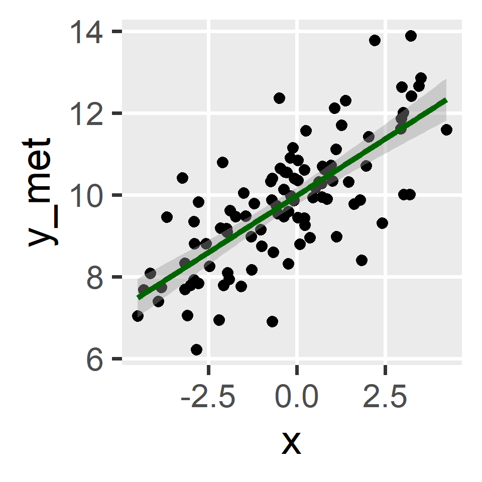

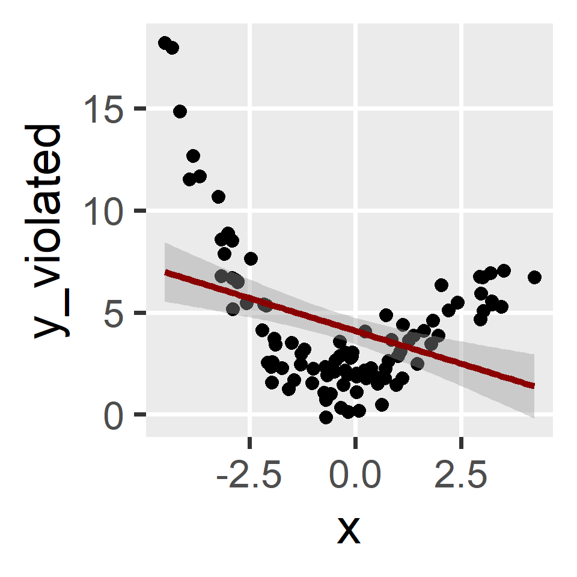

## Diagnostics

- We can use scatterplots as a visual diagnostic
  - A simple approach would plot $y$ against each $x$
  - But we can combine this into a single plot by…
- Plot the residuals $(y-\hat{y})$ against the fitted values $\hat{y}$
  - We can also add a reference (LOESS) line to these plots
  - We want to see a *flat* and *horizontal* reference line

`check_model(fit, check = "linearity")`

## Example: Assumption Met

```r
library(easystats)
check_model(fit_met, check = "linearity")
```

```r
library(easystats)
fit_met <- lm(y_met ~ x, data = d1)
see:::plot.see_check_model(check_model(fit_met, check = "linearity", panel = FALSE))$NCV +
  mytheme() +
  theme(
    plot.title.position = "plot",
    plot.title = element_text(hjust = 0, size = 22),
    plot.subtitle = element_text(hjust = 0, size = 20)
  )
```

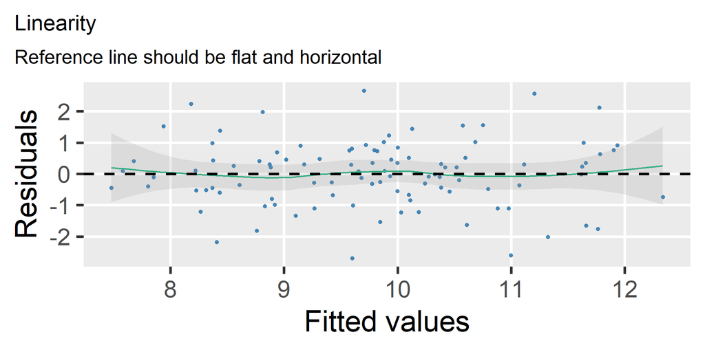

## Example: Assumption Violated

```r
library(easystats)
check_model(fit_violated, check = "linearity")
```

```r
library(easystats)
fit_violated <- lm(y_violated ~ x, data = d1)
see:::plot.see_check_model(check_model(fit_violated, check = "linearity", panel = FALSE))$NCV +
  mytheme() +
  theme(
    plot.title.position = "plot",
    plot.title = element_text(hjust = 0, size = 22),
    plot.subtitle = element_text(hjust = 0, size = 20)
  )
```

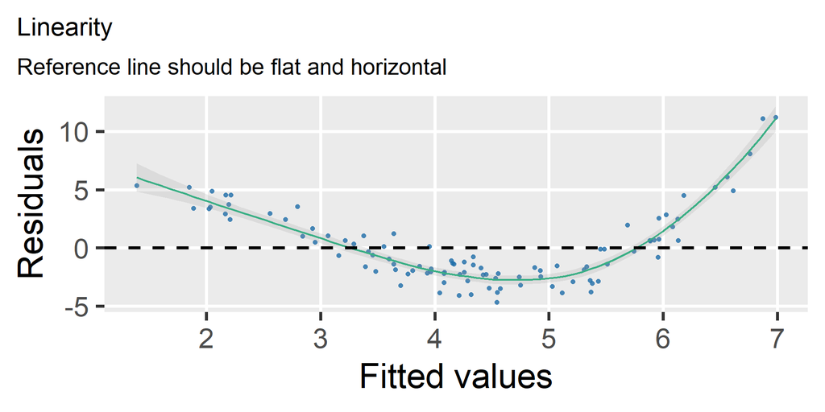

## Solutions

1. Specify a more complex functional form
   - e.g., variable transformations
   - e.g., polynomial regression
   - e.g., segmented or piece-wise regression
2. Use a nonlinear extension of regression
   - e.g., generalized linear modeling (GLM)
   - e.g., generalized additive modeling (GAM)
   - e.g., supervised machine learning (ML)

# Perfect Predictors

## Assumption

- All predictors $(x)$ must be measured without error
  - With a single predictor, the slope will be underestimated
  - With many predictors, slopes may be too low or high
- When violated, called regression “dilution” or “attenuation”

**Consequences of Violating**

Bias in both coefficients and standard errors!

Error in $y$ will bias standardized (but not unstandardized) coefficients.

## Diagnostics

Calculate predictors’ **reliability** (the opposite of error)

1. Test-retest reliability across time
   - Correlation from `correlation::correlation()`
2. Internal reliability across items
   - McDonald’s Omega from `psych::omega()`
3. Inter-rater reliability across raters
   - Intraclass Correlation from `irr::icc()`

## Solutions

1. Improve measurement reliability
   - e.g., add items, raters, or training
2. Adjust coefficients for reliability
   - e.g., correlation disattenuation
3. Model reliability/error explicitly
   - e.g., total least squares estimation
   - e.g., errors-in-variables models
   - e.g., structural equation modeling

# No Collinearity

## Assumption

- No set of predictors are redundant with one another
  - Collinearity = 2 predictors, Multicollinearity = 3+
- If $x_1$ and $x_2$ fully overlap, there are no partial effects left
  - The model won’t fit (or drops one or more predictors)
- If they *almost* fully overlap, the estimates become unstable

## Assumption

If $x_1$ and $x_2$ overlap to a  
*very* large degree, then…

- c and/or d are large
- b and f are unstable

$$\hat{y} = b_0 + b_1x_1 + b_2x_2$$

- So $b_1$ and $b_2$ are unstable

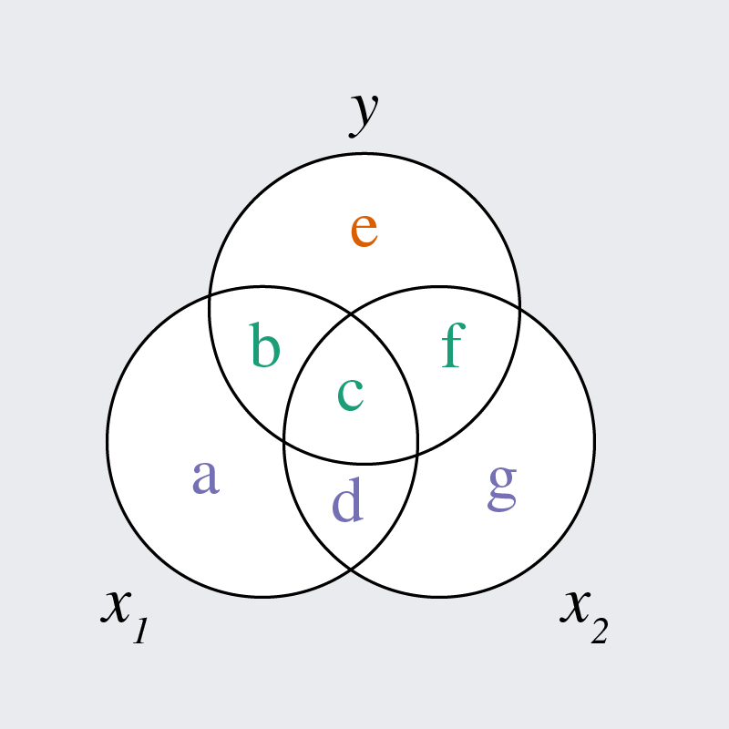

## Diagnostics

1. Examine predictor correlations for collinearity
   - $r(x_1, x_2)\ge0.9$ may be problematic
   - But this captures c and d, whereas only c is an issue
   - It also doesn’t detect multicollinearity
2. Calculate variance inflation factors (VIFs)
   - Look for evidence of inflated standard errors
   - Each predictor will get its own VIF value
   - $\text{VIF}>5$ is “moderate”, $\text{VIF}>10$ is “high”

## Variance Inflation Factors

- To calculate the $\text{VIF}$ for predictor $j$…
  1. Regress $x_j$ on *all other* predictors
  2. Calculate $R^2$ from that model
  3. Calculate $\text{VIF}$ from that $R^2$

$$\text{VIF}_j = \frac{1}{1-R^2_j}$$

`check_collinearity(fit)`

## Example Data

Let’s simulate some data with various collinearity-related issues

#### Simulated Data

- `y` (Continuous)
- `height1`, `height2`, `weight`, `size` (Continuous)
- `female`, `male` (Binary)

#### Simulated Issues

- `height2` is collinear with `height1`
- `size` is multicollinear with `height1` and `weight`
- `female` and `male` are fully redundant

## Bivariate Correlations

```r
round(cor(simdat), digits = 2)
##         height1 height2 weight  size female  male     y
## height1    1.00    0.97   0.07  0.72   0.15 -0.15  0.33
## height2    0.97    1.00   0.09  0.71   0.14 -0.14  0.29
## weight     0.07    0.09   1.00  0.72   0.16 -0.16 -0.66
## size       0.72    0.71   0.72  1.00   0.23 -0.23 -0.22
## female     0.15    0.14   0.16  0.23   1.00 -1.00 -0.05
## male      -0.15   -0.14  -0.16 -0.23  -1.00  1.00  0.05
## y          0.33    0.29  -0.66 -0.22  -0.05  0.05  1.00
```

- `height1` and `height2` are highly correlated $(r=.97)$
- `female` and `male` are perfectly correlated $(r=-1.00)$
- However, `size` is not as correlated with `height1` $(r=.72)$  
  or `weight` $(r=.72)$ despite the three being multicollinear

## Example with No Issues

```r
fit_none <- lm(y ~ height1 + weight, data = simdat)

model_parameters(fit_none)
## Parameter   | Coefficient |   SE |         95% CI |  t(97) |      p
## -------------------------------------------------------------------
## (Intercept) |       10.02 | 0.12 | [ 9.80, 10.25] |  87.06 | < .001
## height1     |        0.20 | 0.04 | [ 0.13,  0.28] |   5.53 | < .001
## weight      |       -0.38 | 0.04 | [-0.45, -0.30] | -10.16 | < .001

r2(fit_none)
## # R2 for Linear Regression
##        R2: 0.567
##   adj. R2: 0.558
```

- Both slopes are significant
- The SE of both slopes is 0.04
- The $R^2$ is 0.567 (57%)

## Example with No Issues

Let’s calculate the VIFs for this model

```r
check_collinearity(fit_none)
## # Check for Multicollinearity
##
## Low Correlation
##
##     Term  VIF       VIF 95% CI adj. VIF Tolerance Tolerance 95% CI
##  height1 1.00 [1.00, 4.50e+15]     1.00      1.00     [0.00, 1.00]
##   weight 1.00 [1.00, 4.50e+15]     1.00      1.00     [0.00, 1.00]
```

- The VIFs for both predictors are low (<5)

## Example with Collinearity

```r
fit_co <- lm(y ~ height1 + weight + height2, data = simdat)

model_parameters(fit_co)
## Parameter   | Coefficient |   SE |         95% CI |  t(96) |      p
## -------------------------------------------------------------------
## (Intercept) |       10.02 | 0.12 | [ 9.79, 10.25] |  86.61 | < .001
## height1     |        0.24 | 0.15 | [-0.05,  0.53] |   1.61 | 0.110
## weight      |       -0.38 | 0.04 | [-0.45, -0.30] | -10.04 | < .001
## height2     |       -0.03 | 0.15 | [-0.32,  0.26] |  -0.23 | 0.821

r2(fit_co)
## # R2 for Linear Regression
##        R2: 0.567
##   adj. R2: 0.553
```

- The `height1` slope is no longer significant
- The SE of the height slopes are both 0.15 (up from 0.04)
- Note that the $R^2$ is basically the same (57%)

## Example with Collinearity

Let’s calculate the VIFs for this model

```r
check_collinearity(fit_co)
## # Check for Multicollinearity
##
## Low Correlation
##
##    Term  VIF       VIF 95% CI adj. VIF Tolerance Tolerance 95% CI
##  weight 1.01 [ 1.00, 5128.00]     1.01      0.99     [0.00, 1.00]
##
## High Correlation
##
##     Term   VIF       VIF 95% CI adj. VIF Tolerance Tolerance 95% CI
##  height1 15.71 [11.06,   22.49]     3.96      0.06     [0.04, 0.09]
##  height2 15.76 [11.10,   22.58]     3.97      0.06     [0.04, 0.09]
```

- The VIFS for both height variables are very high (>10)

## Example with Multicollinearity

```r
fit_mc <- lm(y ~ height1 + weight + size, data = simdat)

model_parameters(fit_mc)
## Parameter   | Coefficient |   SE |         95% CI | t(96) |      p
## ------------------------------------------------------------------
## (Intercept) |       10.02 | 0.12 | [ 9.79, 10.25] | 85.93 | < .001
## height1     |        0.24 | 0.18 | [-0.11,  0.60] |  1.37 | 0.175
## weight      |       -0.34 | 0.18 | [-0.69,  0.01] | -1.92 | 0.058
## size        |       -0.04 | 0.18 | [-0.39,  0.31] | -0.22 | 0.828

r2(fit_mc)
## # R2 for Linear Regression
##        R2: 0.567
##   adj. R2: 0.553
```

- None of the slopes are significant
- The SE of all slopes is now 0.18 (up from 0.04)
- Note that the $R^2$ is basically the same (57%)

## Example with Multicollinearity

Let’s calculate the VIFs for this model

```r
check_collinearity(fit_mc)
## # Check for Multicollinearity
##
## High Correlation
##
##     Term   VIF     VIF 95% CI adj. VIF Tolerance Tolerance 95% CI
##  height1 22.91 [16.05, 32.89]     4.79      0.04     [0.03, 0.06]
##   weight 22.60 [15.84, 32.44]     4.75      0.04     [0.03, 0.06]
##     size 47.41 [33.03, 68.25]     6.89      0.02     [0.01, 0.03]
```

- The VIFs for all predictors are very high (>10)

## Example with Exact Collinearity

```r
fit_xc <- lm(y ~ female + male, data = simdat)

model_parameters(fit_xc)
## Model matrix is rank deficient. Parameters `male` were not estimable.
## Parameter   | Coefficient |   SE |         95% CI | t(98) |      p
## ------------------------------------------------------------------
## (Intercept) |       10.01 | 0.24 | [ 9.52, 10.49] | 40.89 | < .001
## female      |       -0.19 | 0.34 | [-0.87,  0.49] | -0.54 | 0.590
##
## Uncertainty intervals (equal-tailed) and p-values (two-tailed) computed
##   using a Wald t-distribution approximation.
```

- Note the warning about the `male` parameter
- Note the absence of a `male` slope (it was dropped)
- This is why we use $(g-1)$ dummy codes and not $g$

## Solutions

1. Break the predictors’ redundancy
   - e.g., drop one or more predictors
   - e.g., combine two or more predictors
   - e.g., reduce predictor dimensionality (PCA)
   - e.g., penalized (lasso or ridge) regression
2. Model the predictors’ shared variance
   - e.g., partial least squares estimation
   - e.g., structural equation modeling